# Untitled

Salma Elshahawy

9/23/2019

## Problem statement

The Objective of this task is know what are the most frequent words that Trump used in his speeches. This is the code associated with project_1 presentation for DATA_607 MSDS CUNY University. The full presentation is [here](https://docs.google.com/presentation/d/1sva8rneqBU76zE3Xr8BZI9T7RKZZJg_M0_5On9Tc744/edit?usp=sharing)

## Loading Texts

Start by saving your text files in a folder titled: “texts” This will be the “corpus” (body) of texts you are mining.

Note: The texts used in this example are a few of Donald Trump’s speeches that were copied and pasted into a text document.

```r
text_name <- file.path("~", "Desktop", "texts")
text_name
```

```
## [1] "~/Desktop/texts"
```

```r
dir(text_name)
```

```
##  [1] "Trump Black History Month Speech.txt"
##  [2] "Trump CIA Speech.txt"
##  [3] "Trump Congressional Address.txt"
##  [4] "Trump CPAC Speech.txt"
##  [5] "Trump Florida Rally 2-18-17.txt"
##  [6] "Trump Immigration Speech 8-31-16.txt"
##  [7] "Trump Inauguration Speech.txt"
##  [8] "Trump National Prayer Breakfast.txt"
##  [9] "Trump Nomination Speech.txt"
## [10] "Trump Police Chiefs Speech.txt"
## [11] "Trump Response to Healthcare Bill Failure.txt"
```

Load the R package for text mining and then load your texts into R.

VCorpus in tm refers to “Volatile” corpus which means that the corpus is stored in memory and would be destroyed when the R object containing it is destroyed.

Contrast this with PCorpus or Permanent Corpus which are stored outside the memory say in a db.

In order to create a VCorpus using tm, we need to pass a “Source” object as a paramter to the VCorpus method. You can find the sources available using this method - getSources()

I refered to this post on [stackoverflow](https://stats.stackexchange.com/questions/164372/what-is-vectorsource-and-vcorpus-in-tm-text-mining-package-in-r)

```r
library(tm)
docs <- VCorpus(DirSource(text_name))
summary(docs)
```

```
##                                               Length Class
## Trump Black History Month Speech.txt          2      PlainTextDocument
## Trump CIA Speech.txt                          2      PlainTextDocument
## Trump Congressional Address.txt               2      PlainTextDocument
## Trump CPAC Speech.txt                         2      PlainTextDocument
## Trump Florida Rally 2-18-17.txt               2      PlainTextDocument
## Trump Immigration Speech 8-31-16.txt          2      PlainTextDocument
## Trump Inauguration Speech.txt                 2      PlainTextDocument
## Trump National Prayer Breakfast.txt           2      PlainTextDocument
## Trump Nomination Speech.txt                   2      PlainTextDocument
## Trump Police Chiefs Speech.txt                2      PlainTextDocument
## Trump Response to Healthcare Bill Failure.txt 2      PlainTextDocument
##                                               Mode
## Trump Black History Month Speech.txt          list
## Trump CIA Speech.txt                          list
## Trump Congressional Address.txt               list
## Trump CPAC Speech.txt                         list
## Trump Florida Rally 2-18-17.txt               list
## Trump Immigration Speech 8-31-16.txt          list
## Trump Inauguration Speech.txt                 list
## Trump National Prayer Breakfast.txt           list
## Trump Nomination Speech.txt                   list
## Trump Police Chiefs Speech.txt                list
## Trump Response to Healthcare Bill Failure.txt list
```

```r
inspect(docs[1])
```

```
## <<VCorpus>>
## Metadata:  corpus specific: 0, document level (indexed): 0
## Content:  documents: 1
##
## [[1]]
## <<PlainTextDocument>>
## Metadata:  7
## Content:  chars: 3974
```

```r
writeLines(as.character(docs[1]))
```

[output not shown]

## Removing the punctuation

I used tm_map to remove all the puncituations from all the documents in the corpus.

```r
docs <- tm_map(docs,removePunctuation)
# writeLines(as.character(docs[1])) # Check to see if it worked.
    # The 'writeLines()' function is commented out to save space.
docs
```

```
## <<VCorpus>>
## Metadata:  corpus specific: 0, document level (indexed): 0
## Content:  documents: 11
```

also used regex to remove ASCII characters

```r
for (j in seq(docs)) {
    docs[[j]] <- gsub("/", " ", docs[[j]])
    docs[[j]] <- gsub("@", " ", docs[[j]])
    docs[[j]] <- gsub("\\|", " ", docs[[j]])
    docs[[j]] <- gsub("\u2028", " ", docs[[j]])  # This is an ascii character that did not translate, so it had to be removed.
}
#writeLines(as.character(docs[1])) # You can check a document (in this case
# the first) to see if it worked.
```

## Removing numbers

```r
docs <- tm_map(docs, removeNumbers)
#writeLines(as.character(docs[1])) # Check to see if it worked.
```

## Converting to lowercase

As before, we want a word to appear exactly the same every time it appears. We therefore change everything to lowercase.

```r
docs <- tm_map(docs, tolower)
docs <- tm_map(docs, PlainTextDocument)
DocsCopy <- docs
# writeLines(as.character(docs[1])) # Check to see if it worked.
```

## Removing “stopwords”

(common words) that usually have no analytic value. In every text, there are a lot of common, and uninteresting words (a, and, also, the, etc.). Such words are frequent by their nature, and will confound your analysis if they remain in the text.

```r
# For a list of the stopwords, see:
# length(stopwords("english"))
# stopwords("english")
docs <- tm_map(docs, removeWords, stopwords("english"))
docs <- tm_map(docs, PlainTextDocument)
# writeLines(as.character(docs[1])) # Check to see if it worked.
```

```r
docs <- tm_map(docs, removeWords, c("syllogism", "tautology"))
# Just remove the words "syllogism" and "tautology".
# These words don't actually exist in these texts. But this is how you would remove them if they had.
```

## Combining words that should stay together

If you wish to preserve a concept is only apparent as a collection of two or more words, then you can combine them or reduce them to a meaningful acronym before you begin the analysis. Here, I am using examples that are particular to qualitative data analysis.

```r
for (j in seq(docs))
{
  docs[[j]] <- gsub("fake news", "fake_news", docs[[j]])
  docs[[j]] <- gsub("inner city", "inner-city", docs[[j]])
  docs[[j]] <- gsub("politically correct", "politically_correct", docs[[j]])
}
docs <- tm_map(docs, PlainTextDocument)
```

## Removing common word endings (e.g., “ing”, “es”, “s”)

This is referred to as “stemming” documents. We stem the documents so that a word will be recognizable to the computer, despite whether or not it may have a variety of possible endings in the original text.

Note: The “stem completion” function is currently problemmatic, and stemmed words are often annoying to read. For now, I have this section commented out. But you are welcome to try these functions (by removing the hashmark from the beginning of the line) if they interest you. Just don’t expect them to operate smoothly.

This procedure has been a little hanky in the recent past, so I change the name of the data object when I do this to keep from overwriting what I have done to this point.

```r
docs_st <- tm_map(docs, stemDocument)
docs_st <- tm_map(docs_st, PlainTextDocument)
writeLines(as.character(docs_st[1])) # Check to see if it worked.
```

[output not shown]

```r
# docs <- docs_st
```

```r
docs <- tm_map(docs, stripWhitespace)
# writeLines(as.character(docs[1])) # Check to see if it worked.
```

```r
docs <- tm_map(docs, PlainTextDocument)
```

## Stage the Data

To proceed, create a document term matrix. This is what you will be using from this point on.

```r
dtm <- DocumentTermMatrix(docs)
dtm
```

```
## <<DocumentTermMatrix (documents: 11, terms: 3659)>>
## Non-/sparse entries: 8364/31885
## Sparsity           : 79%
## Maximal term length: 19
## Weighting          : term frequency (tf)
```

You’ll also need a transpose of this matrix. Create it using:

```r
tdm <- TermDocumentMatrix(docs)
tdm
```

```
## <<TermDocumentMatrix (terms: 3659, documents: 11)>>
## Non-/sparse entries: 8364/31885
## Sparsity           : 79%
## Maximal term length: 19
## Weighting          : term frequency (tf)
```

## Explore the data

Organize terms by their frequency:

```r
freq <- colSums(as.matrix(dtm))
length(freq)
```

```
## [1] 3659
```

```r
ord <- order(freq)
```

```r
m <- as.matrix(dtm)
dim(m)
```

```
## [1]   11 3659
```

## Write to a csv file

```r
write.csv(m, file="DocumentTermMatrix.csv")
```

The ‘removeSparseTerms()’ function will remove the **infrequently** used words, leaving only the most well-used words in the corpus.

```r
#  Start by removing sparse terms:
dtms <- removeSparseTerms(dtm, 0.2) # This makes a matrix that is 20% empty space, maximum.
dtms
```

```
## <<DocumentTermMatrix (documents: 11, terms: 87)>>
## Non-/sparse entries: 848/109
## Sparsity           : 11%
## Maximal term length: 11
## Weighting          : term frequency (tf)
```

## Word Frequency

There are a lot of terms, so for now, just check out some of the most and least frequently occurring words.

```r
freq <- colSums(as.matrix(dtm))
```

```r
head(table(freq), 20) # The ", 20" indicates that we only want the first 20 frequencies. Feel free to change that number.
```

```
## freq
##    1    2    3    4    5    6    7    8    9   10   11   12   13   14   15
## 1638  626  326  212  123  103   81   60   59   45   38   33   29   25   26
##   16   17   18   19   20
##   16    9   13   16   11
```

For a look at the most frequently used terms, we can use the ‘tail()’ function.

```r
tail(table(freq), 20) # The ", 20" indicates that we only want the last 20 frequencies.  Feel free to change that number, as needed.
```

```
## freq
##  77  79  83  88  89 100 101 102 105 107 111 122 127 139 140 163 174 265
##   1   2   2   1   1   1   1   1   1   1   1   1   1   1   1   1   1   1
## 278 428
##   1   1
```

For a less, fine-grained look at term freqency we can view a table of the terms we selected when we removed sparse terms, above.

```r
freq <- colSums(as.matrix(dtms))
freq
```

```
##        also      always     america    american     another        back
##          54          24         122         107          22          75
##         bad     believe         big        came         can        care
##          35          60          45          20         100          37
##        come     country         day   different        done enforcement
##          55         174          36          16          24          43
##        even        ever       every         get     getting        give
##          55          42          49          79          23          25
##       going        good       great       group      happen         job
##         265          58         163          20          36          38
##        just        know        last         law         let        life
##          88         127          44          59          40          27
##        like      little        long        look         lot        love
##          79          24          36          52          44          45
##        made        many        much        must      nation        need
##          32         101          68          53          48          32
##       never         new         now      office         one      people
##          83          69         111          24         139         278
##   president         put      really    remember       right        safe
##          44          35          57          27         102          35
##        said         say         see        seen   something     special
##          83          66          48          34          25          26
##      states        take        tell       thank      things       think
##          65          64          50         105          40          77
##        time       today    together     totally       truly  understand
##          76          33          34          18          16          29
##      united        want         way        well        will        work
##          64         140          71          51         428          64
##       world        year       years
##          56          47          54
```

```r
freq <- sort(colSums(as.matrix(dtm)), decreasing=TRUE)
head(freq, 14)
```

```
##     will   people    going  country    great     want      one     know
##      428      278      265      174      163      140      139      127
##  america      now american    thank    right     many
##      122      111      107      105      102      101
```

An alternate view of term frequency: This will identify all terms that appear frequently (in this case, 50 or more times).

```r
findFreqTerms(dtm, lowfreq=50)
```

```
##  [1] "’re"         "also"        "america"     "american"    "back"
##  [6] "believe"     "can"         "come"        "country"     "dont"
## [11] "even"        "get"         "going"       "good"        "great"
## [16] "immigration" "jobs"        "just"        "know"        "law"
## [21] "like"        "look"        "make"        "many"        "much"
## [26] "must"        "never"       "new"         "now"         "one"
## [31] "people"      "really"      "right"       "said"        "say"
## [36] "states"      "take"        "tell"        "thank"       "theyre"
## [41] "think"       "time"        "united"      "want"        "way"
## [46] "well"        "will"        "work"        "world"       "years"
```

**View as a table**:

```r
wf <- data.frame(word=names(freq), freq=freq)
head(wf)
```

|  | word | freq |
| --- | --- | --- |
| will | will | 428 |
| people | people | 278 |
| going | going | 265 |
| country | country | 174 |
| great | great | 163 |
| want | want | 140 |

## Visualizing

Plot words that appear at least 50 times.

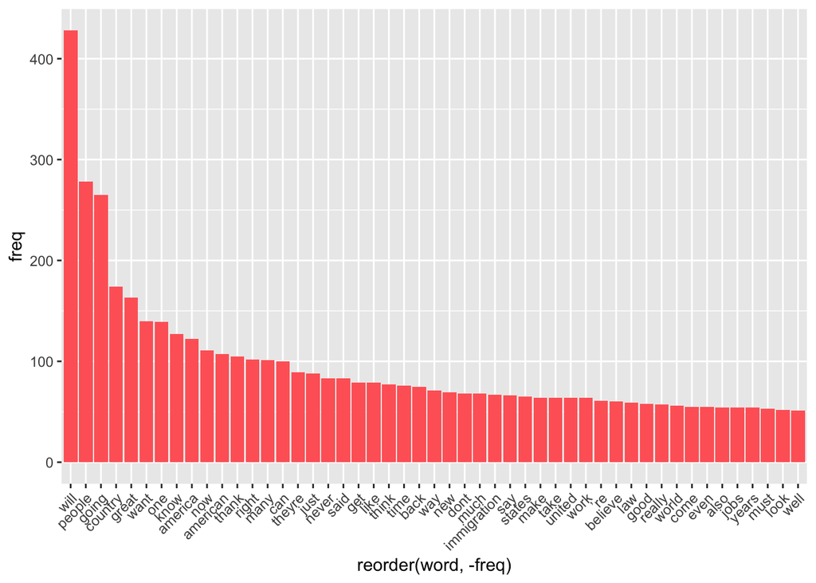

```r
library(ggplot2)
p <- ggplot(subset(wf, freq>50), aes(x = reorder(word, -freq), y = freq)) +
          geom_bar(stat = "identity", fill = "#FF6666") +
          theme(axis.text.x=element_text(angle=45, hjust=1))
p
```

## Relationships Between Terms

**Term Correlations**

If we have a term in mind that we have found to be particularly meaningful to our analysis, then we may find it helpful to identify the words that most highly correlate with that term.

If words always appear together, then correlation=1.0.

```r
findAssocs(dtm, c("country" , "american"), corlimit=0.85) # specifying a correlation limit of 0.85
```

```
## $country
##   nothing    cities countries      jobs      come   biggest    donors
##      0.95      0.94      0.94      0.92      0.91      0.90      0.90
##    second     begin    border      plan    crimes     globe     meant
##      0.90      0.88      0.88      0.88      0.87      0.87      0.87
## thousands     means   workers      also   despite      take
##      0.87      0.86      0.86      0.85      0.85      0.85
##
## $american
##  restore     task     fair   budget    cycle      new promises  dollars
##     0.97     0.93     0.92     0.91     0.89     0.89     0.89     0.88
##  finally millions national     tens  foreign   middle  justice  program
##     0.88     0.88     0.88     0.88     0.87     0.87     0.86     0.86
##    break  joining   united
##     0.85     0.85     0.85
```

```r
findAssocs(dtms, "think", corlimit=0.70) # specifying a correlation limit of 0.95
```

```
## $think
## really   well   care    lot happen    see   good
##   0.89   0.88   0.86   0.76   0.72   0.72   0.71
```

## Word Clouds!

Humans are generally strong at visual analytics. That is part of the reason that these have become so popular. What follows are a variety of alternatives for constructing word clouds with your text.

But first you will need to load the package that makes word clouds in R.

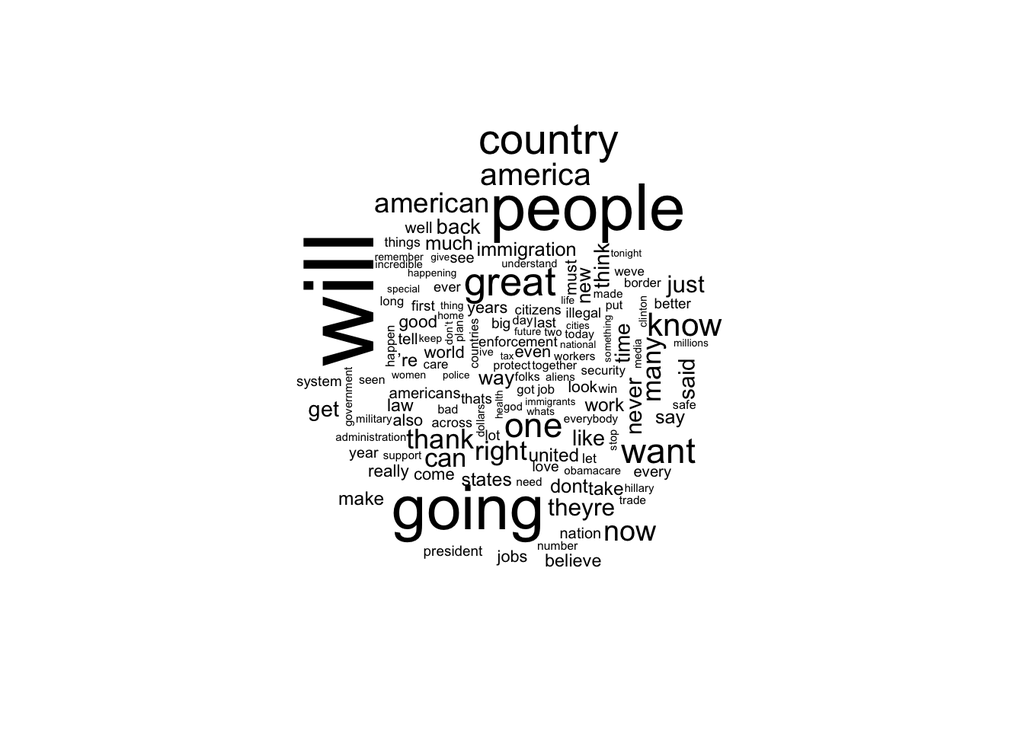

```r
library(tm)
library(tmap)
library(wordcloud)
set.seed(142)

wordcloud(names(freq), freq, min.freq=25, scale = c(4, 0.2))
```

Plot the 100 most frequently used words.

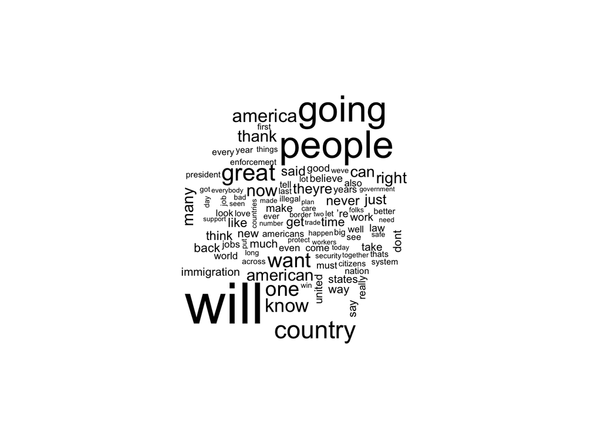

```r
set.seed(142)
wordcloud(names(freq), freq, max.words=100, scale = c(4, 0.2))
```

Add some color and plot words occurring at least 20 times.

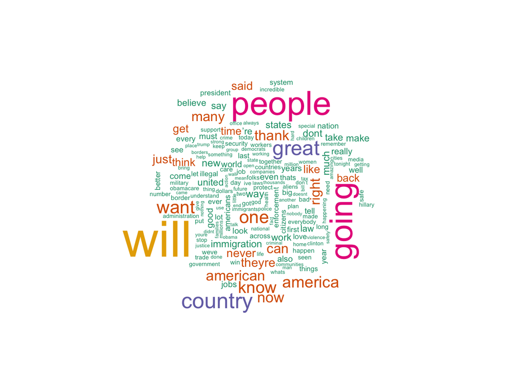

```r
set.seed(142)
wordcloud(names(freq), freq, min.freq=20, scale = c(4, 0.2), colors=brewer.pal(6, "Dark2"))
```

Plot the 100 most frequently occurring words.

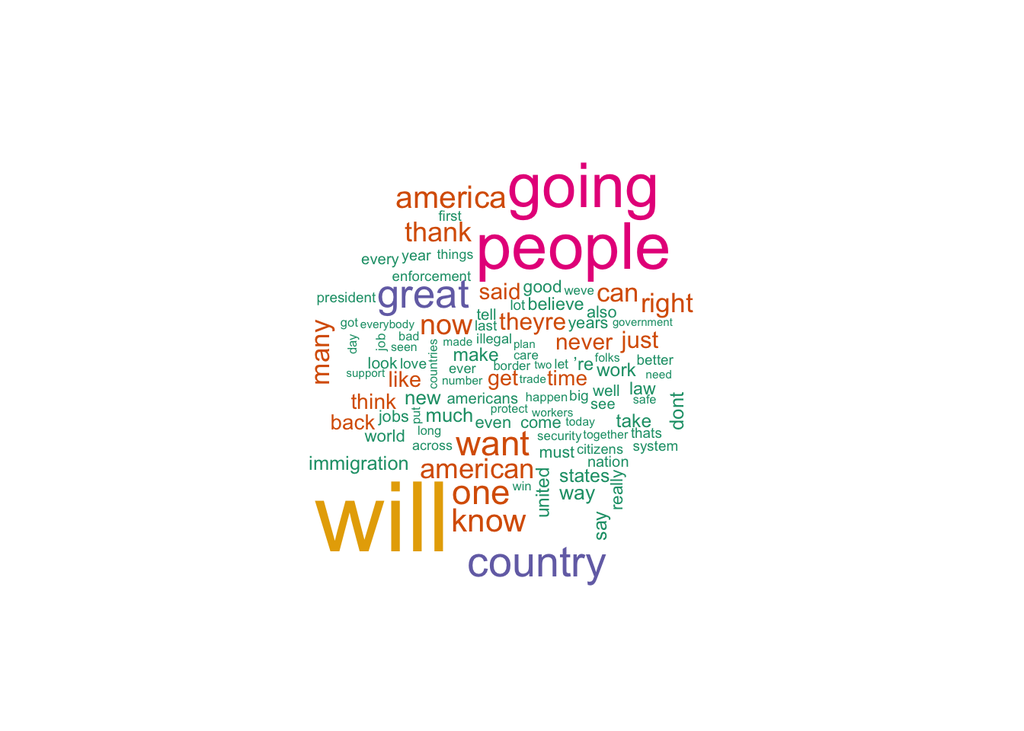

```r
set.seed(142)
dark2 <- brewer.pal(6, "Dark2")
wordcloud(names(freq), freq, max.words=100, scale = c(4, 0.2), colors=dark2)
```

## Clustering by Term Similarity

To do this, we should always first remove a lot of the uninteresting or infrequent words.

```r
dtmss <- removeSparseTerms(dtm, 0.15) # This makes a matrix that is only 15% empty space, maximum.
dtmss
```

```
## <<DocumentTermMatrix (documents: 11, terms: 43)>>
## Non-/sparse entries: 452/21
## Sparsity           : 4%
## Maximal term length: 9
## Weighting          : term frequency (tf)
```

## Hierarchal Clustering

First calculate distance between words & then cluster them according to similarity.

```r
library(cluster)
d <- dist(t(dtmss), method="euclidian")
fit <- hclust(d=d, method="complete")   # for a different look try substituting: method="ward.D"
fit
```

```
##
## Call:
## hclust(d = d, method = "complete")
##
## Cluster method   : complete
## Distance         : euclidean
## Number of objects: 43
```

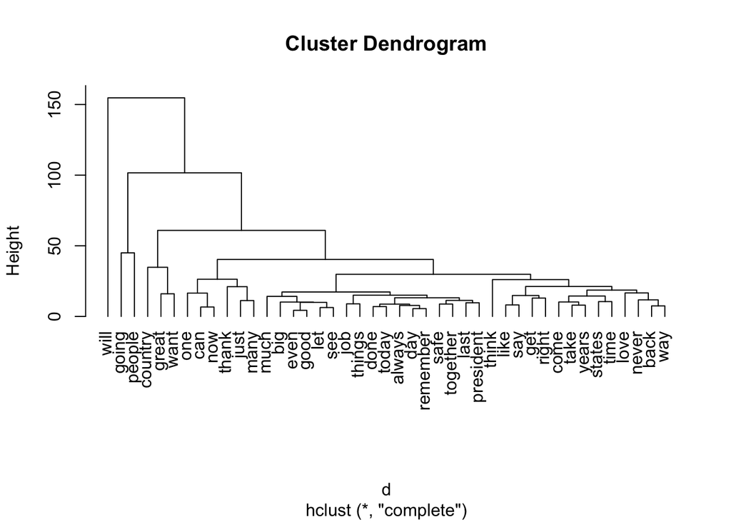

```r
plot(fit, hang=-1)
```

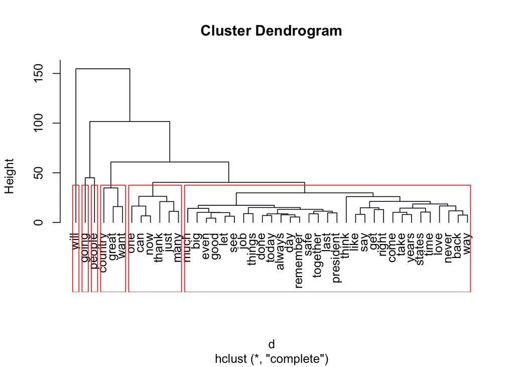

```r
plot.new()
plot(fit, hang=-1)
groups <- cutree(fit, k=6)   # "k=" defines the number of clusters you are using
rect.hclust(fit, k=6, border="red") # draw dendogram with red borders around the 6 clusters
```